# Project: Data-driven Insights using Python: FoodHub Data Analysis

# Problem Statement

## Context

The number of restaurants in New York is increasing day by day. Lots of students and busy professionals rely on those restaurants due to their hectic lifestyles. An online food delivery service is a great option for them. It provides them with good food from their favorite restaurants. A food aggregator company FoodHub, offers access to multiple restaurants through a single smartphone app. The app allows the restaurants to receive a direct online order from a customer. The app assigns a delivery person from the company to pick up the order after it is confirmed by the restaurant. The delivery person then uses the map to reach the restaurant and waits for the food package. Once the food package is handed over to the delivery person, he/she confirm the pick-up in the app and travel to the customer's location to deliver the food. The delivery person confirms the drop-off in the app after delivering the food package to the customer. The customer can rate the order in the app. The food aggregator earns money by collecting a fixed margin of the delivery order from the restaurants.

## Objective

The food aggregator company has stored the data of the different orders made by the registered customers in its online portal. They want to analyze the data to get a fair idea about the demand for different restaurants, which will help them enhance their customer experience. Suppose you are hired as a Data Scientist in this company, and the Data Science team has shared some of the key questions that need to be answered. Perform the data analysis to find answers to these questions that will help the company improve its business.

## Data Description

The data contains different data related to a food order. The detailed data dictionary is given below.

- order_id: Unique ID of the order
- customer_id: ID of the customer who ordered the food
- restaurant_name: Name of the restaurant
- cuisine_type: Cuisine ordered by the customer
- cost_of_the_order: Cost of the order
- day_of_the_week: Indicates whether the order is placed on a weekday or weekend (The weekday is from Monday to Friday and the weekend is Saturday and Sunday)
- rating: Rating given by the customer out of 5
- food_preparation_time: Time (in minutes) taken by the restaurant to prepare the food. This is calculated by taking the difference between the timestamps of the restaurant's order confirmation and the delivery person's pick-up confirmation.
- delivery_time: Time (in minutes) taken by the delivery person to deliver the food package. This is calculated by taking the difference between the timestamps of the delivery person's pick-up confirmation and drop-off information

# Let us start by importing the required libraries

```python
# Installing the libraries with the specified version.
!pip install numpy pandas matplotlib seaborn -q --user
```

**Note**:

- After running the above cell, kindly restart the runtime (for Google Colab) or notebook kernel (for Jupyter Notebook), and run all cells sequentially from the next cell.
- On executing the above line of code, you might see a warning regarding package dependencies. This error message can be ignored as the above code ensures that all necessary libraries and their dependencies are maintained to successfully execute the code in **this notebook**.

```python
# Import libraries for data manipulation
import numpy as np
import pandas as pd

# Import libraries for data visualization
import matplotlib.pyplot as plt
import seaborn as sns
```

# Understanding the structure of the data

```python
#uncomment and run the below code snippets if the dataset is present in the Google Drive
from google.colab import drive
drive.mount('/content/drive')
```

```python
# Read the data
file_path = '/content/drive/MyDrive/Python Course/Project1_Data-driven Insights using Python: FoodHub/foodhub_order.csv'
df = pd.read_csv(file_path)
```

```python
#  view the first 5 rows

df.head() # returns first 5 rows
```

|  | order_id | customer_id | restaurant_name | cuisine_type | cost_of_the_order | day_of_the_week | rating | food_preparation_time | delivery_time |
| --- | --- | --- | --- | --- | --- | --- | --- | --- | --- |
| 0 | 1477147 | 337525 | Hangawi | Korean | 30.75 | Weekend | Not given | 25 | 20 |
| 1 | 1477685 | 358141 | Blue Ribbon Sushi Izakaya | Japanese | 12.08 | Weekend | Not given | 25 | 23 |
| 2 | 1477070 | 66393 | Cafe Habana | Mexican | 12.23 | Weekday | 5 | 23 | 28 |
| 3 | 1477334 | 106968 | Blue Ribbon Fried Chicken | American | 29.20 | Weekend | 3 | 25 | 15 |
| 4 | 1478249 | 76942 | Dirty Bird to Go | American | 11.59 | Weekday | 4 | 25 | 24 |

### **Question 1:** How many rows and columns are present in the data? [0.5 mark]

```python
#Get the no. of Rows and Columns from the dataset
#df.shape is a Pandas attribute that tells us the size of the datafrom
print("Rows:", df.shape[0]) #df.shape[0] gives the no. of rows
print("Columns:", df.shape[1]) #df.shape[1] gives the no. of columns
```

```
Rows: 1898
Columns: 9
```

#### Observations: There are 1898 rows of data in the Dataframe and 9 columns.

### **Question 2:** What are the datatypes of the different columns in the dataset? (The info() function can be used) [0.5 mark]

```python
# dtypedf.dtypes
df.info() #Shows for each column: columnname, Non-null count and Datatype(dtype)
```

```
<class 'pandas.core.frame.DataFrame'>
RangeIndex: 1898 entries, 0 to 1897
Data columns (total 9 columns):
 #   Column                 Non-Null Count  Dtype
---  ------                 --------------  -----
 0   order_id               1898 non-null   int64
 1   customer_id            1898 non-null   int64
 2   restaurant_name        1898 non-null   object
 3   cuisine_type           1898 non-null   object
 4   cost_of_the_order      1898 non-null   float64
 5   day_of_the_week        1898 non-null   object
 6   rating                 1898 non-null   object
 7   food_preparation_time  1898 non-null   int64
 8   delivery_time          1898 non-null   int64
dtypes: float64(1), int64(4), object(4)
memory usage: 133.6+ KB
```

#### Observations:

- There 1898 rows of data with no Null data in any of the columns.
- There are 9 columns ina given dataset : 1 column float64(1), 4 coulmns(order_id, customer_id,food_preparation_time,delivery_time ) with int64 dtype, 4 coulmns( restaurant_name, cuisine_type ,day_of_the_week , rating ) with object(4) datatype

### **Question 3:** Are there any missing values in the data? If yes, treat them using an appropriate method. [1 mark]

```python
# Checking missing values in the data
df.isnull().sum() #isnull() is a pandas method used to detect missing (null) values in a dataset.
```

|  | 0 |
| --- | --- |
| order_id | 0 |
| customer_id | 0 |
| restaurant_name | 0 |
| cuisine_type | 0 |
| cost_of_the_order | 0 |
| day_of_the_week | 0 |
| rating | 0 |
| food_preparation_time | 0 |
| delivery_time | 0 |

**dtype:** int64

#### Observations:

- The dataset does not contain missing values, no missing value treatment is required.
- Missing values would be handled using median/mean imputation for numerical variables and mode imputation for categorical variables.

### **Question 4:** Check the statistical summary of the data. What is the minimum, average, and maximum time it takes for food to be prepared once an order is placed? [2 marks]

```python
# statistics of numerical data
df.describe() # gives the statistical summary of the dataset; numerical columns only
```

|  | order_id | customer_id | cost_of_the_order | food_preparation_time | delivery_time |
| --- | --- | --- | --- | --- | --- |
| count | 1.898000e+03 | 1898.000000 | 1898.000000 | 1898.000000 | 1898.000000 |
| mean | 1.477496e+06 | 171168.478398 | 16.498851 | 27.371970 | 24.161749 |
| std | 5.480497e+02 | 113698.139743 | 7.483812 | 4.632481 | 4.972637 |
| min | 1.476547e+06 | 1311.000000 | 4.470000 | 20.000000 | 15.000000 |
| 25% | 1.477021e+06 | 77787.750000 | 12.080000 | 23.000000 | 20.000000 |
| 50% | 1.477496e+06 | 128600.000000 | 14.140000 | 27.000000 | 25.000000 |
| 75% | 1.477970e+06 | 270525.000000 | 22.297500 | 31.000000 | 28.000000 |
| max | 1.478444e+06 | 405334.000000 | 35.410000 | 35.000000 | 33.000000 |

#### Observations:

FoodPreparation Time:

- The food preparation time ranges from a minimum of 20 minutes to a maximum of 35 minutes, with an average preparation time of approximately 27 minutes.

Cost of Order

- The cost of an order ranges from a 4.47 dollars to 35.41 dollars, with an average cost of an order aprroximately $16.49.

### **Question 5:** How many orders are not rated? [1 mark]

```python
# Orders ratings
df['rating'].value_counts()  #value_counts() is a Pandas function used to count how many times each unique value appears in a column
```

| rating | count |
| --- | --- |
| Not given | 736 |
| 5 | 588 |
| 4 | 386 |
| 3 | 188 |

**dtype:** int64

#### Observations:

- There are missing or unspecified ratings the most with 736(Not given)
- There are 588 orders with 5 rating followed by 386 orders with 4 ratings and 188 orders with 3 ratings.
- There are no Orders with 1 or 2 ratings.

# Exploratory Data Analysis (EDA)

## Univariate Analysis

### **Question 6:** Explore all the variables and provide observations on their distributions. (Generally, histograms, boxplots, countplots, etc. are used for univariate exploration.) [9 marks]

```python
df.head()
```

|  | order_id | customer_id | restaurant_name | cuisine_type | cost_of_the_order | day_of_the_week | rating | food_preparation_time | delivery_time |
| --- | --- | --- | --- | --- | --- | --- | --- | --- | --- |
| 0 | 1477147 | 337525 | Hangawi | Korean | 30.75 | Weekend | Not given | 25 | 20 |
| 1 | 1477685 | 358141 | Blue Ribbon Sushi Izakaya | Japanese | 12.08 | Weekend | Not given | 25 | 23 |
| 2 | 1477070 | 66393 | Cafe Habana | Mexican | 12.23 | Weekday | 5 | 23 | 28 |
| 3 | 1477334 | 106968 | Blue Ribbon Fried Chicken | American | 29.20 | Weekend | 3 | 25 | 15 |
| 4 | 1478249 | 76942 | Dirty Bird to Go | American | 11.59 | Weekday | 4 | 25 | 24 |

```python
# To get unique values from the 'order_id' column
display(df['order_id'].nunique())
```

```
1898
```

Observations: There are 1898 unique orders.

```python
# To get unique values from the 'customer_id' column
df['customer_id'].nunique()
```

```
1200
```

- There are 1200 unique customers in the dataset

```python
# Customer id count
df['customer_id'].value_counts()
```

| customer_id | count |
| --- | --- |
| 52832 | 13 |
| 47440 | 10 |
| 83287 | 9 |
| 250494 | 8 |
| 259341 | 7 |
| ... | ... |
| 143926 | 1 |
| 89574 | 1 |
| 157711 | 1 |
| 66393 | 1 |
| 358141 | 1 |

1200 rows × 1 columns

**dtype:** int64

Observations:

1. Customer 52832 ordered 13 times → the most frequent.
2. Customers 47440 and 83287 ordered 10 and 9 times, respectively.
3. Many customers ordered only once.

```python
df['restaurant_name'].nunique()
```

```
178
```

Observations: There are 178 Unique Restaurant Names in the dataset.

```python
#how many times each unique cuisine type appears in the 'cuisine_type' column of a given dataset
df['restaurant_name'].value_counts()
```

| restaurant_name | count |
| --- | --- |
| Shake Shack | 219 |
| The Meatball Shop | 132 |
| Blue Ribbon Sushi | 119 |
| Blue Ribbon Fried Chicken | 96 |
| Parm | 68 |
| ... | ... |
| Rye House | 1 |
| Hiroko's Place | 1 |
| Frank Restaurant | 1 |
| Sarabeth's West | 1 |
| 'wichcraft | 1 |

178 rows × 1 columns

**dtype:** int64

- Shake Shack is the most popular restaurant with 219 orders.
- Majority of restaurants are with very few orders, with many receiving just 1 order.
- Top 4-5 restaurants are Shake Shack, The Meatball Shop with 132 orders foloowed by Blue Ribbon Sushi with 119 orders and Blue Ribbon Fried Chicken with 96 orders.

```python
#how many times each unique cuisine type appears in the 'cuisine_type' column of a given dataset
df['cuisine_type'].value_counts()
```

| cuisine_type | count |
| --- | --- |
| American | 584 |
| Japanese | 470 |
| Italian | 298 |
| Chinese | 215 |
| Mexican | 77 |
| Indian | 73 |
| Middle Eastern | 49 |
| Mediterranean | 46 |
| Thai | 19 |
| French | 18 |
| Southern | 17 |
| Korean | 13 |
| Spanish | 12 |
| Vietnamese | 7 |

**dtype:** int64

1.Most popular cuisines:

American: 584 orders --> most frequent

Japanese: 470 orders

Italian: 298 orders

2.Moderately popular cuisines:

Chinese (215), Mexican (77), Indian (73)

3.Least popular cuisines:

Thai (19), French (18), Southern (17), Korean (13), Spanish (12), Vietnamese (7)

```python
#get distinct cuisine_type
no_of_unique_cuisines = df['cuisine_type'].nunique()  #gets the count of unique cuisine type
list_of_unique_cuisines = df['cuisine_type'].unique() #list of cusinie types
print('No.of Unique Cuisines are: ',no_of_unique_cuisines)
print('Names of Unique Cuisines : ',list_of_unique_cuisines)
```

```
No.of Unique Cuisines are:  14
Names of Unique Cuisines :  ['Korean' 'Japanese' 'Mexican' 'American' 'Indian' 'Italian'
 'Mediterranean' 'Chinese' 'Middle Eastern' 'Thai' 'Southern' 'French'
 'Spanish' 'Vietnamese']
```

Observations: There are 14 unique Cuisine Types in the dataset

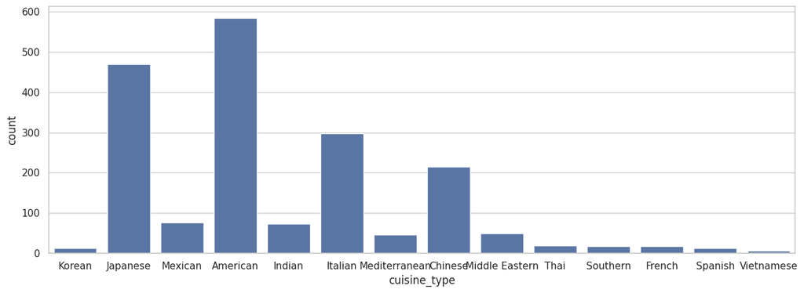

```python
plt.figure(figsize = (15,5)) #sets up a new plot figure with a width of 15 inches and a height of 5 inches
sns.countplot(data = df, x = 'cuisine_type') # creates a bar chart showing the count of each unique 'cuisine_type'
```

- Most popular cusinie type ordered is American(584) followed by Japanese(470),Italian(298) and Chinese(215).
- Thai, Southern, French, Korean, Spanish, Vietnamese all have very low order counts (<20)

```python
#get cost of the order
order_cost_counts = df['cost_of_the_order'].value_counts()
display(order_cost_counts)
```

| cost_of_the_order | count |
| --- | --- |
| 12.18 | 86 |
| 12.13 | 82 |
| 12.23 | 47 |
| 24.20 | 42 |
| 29.10 | 37 |
| ... | ... |
| 7.66 | 1 |
| 10.86 | 1 |
| 7.95 | 1 |
| 20.86 | 1 |
| 29.59 | 1 |

312 rows × 1 columns

**dtype:** int64

- There are 86 orders that cost 12.18 dollars , 82 orders that cost $12.13

```python
max_cost = df['cost_of_the_order'].max()
min_cost = df['cost_of_the_order'].min()

print(f"Maximum cost of an order: {max_cost:.2f}")
print(f"Minimum cost of an order: {min_cost:.2f}")
```

```
Maximum cost of an order: 35.41
Minimum cost of an order: 4.47
```

- Maximum cost of an order: $35.41
- Minimum cost of an order: $4.47

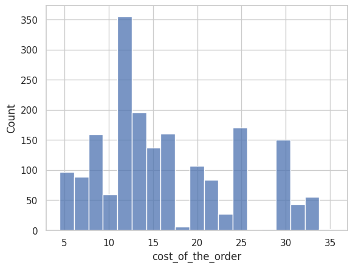

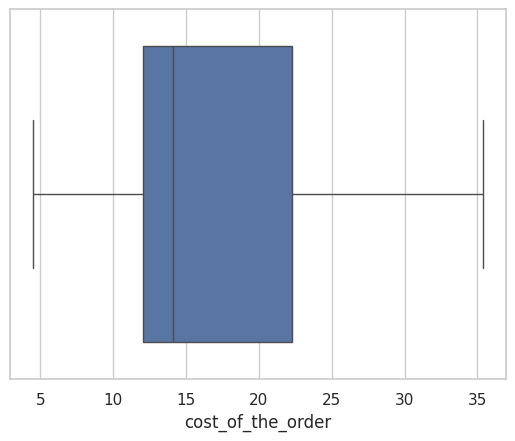

```python
sns.histplot(data=df,x='cost_of_the_order') ## Histogram for the cost of order
plt.show()
sns.boxplot(data=df,x='cost_of_the_order') ## Boxplot for the cost of order
plt.show()
```

1. **Histogram Observations:** The most frequent order cost falls between 11 dollars and $13, with over 350 orders in that price range.
2. **BoxPlot Observations:** The vertical line inside the box shows that the median cost is approximately 14dollars . This means half of all orders cost less than $14, and half cost more.

```python
# # Check the unique values
df['day_of_the_week'].value_counts()
```

| day_of_the_week | count |
| --- | --- |
| Weekend | 1351 |
| Weekday | 547 |

**dtype:** int64

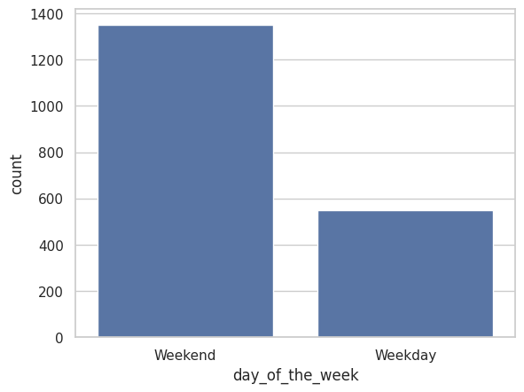

```python
sns.countplot(data = df, x = 'day_of_the_week')
```

- There are more orders over the weekend when compared to a weekday.

```python
df['rating'].value_counts()
```

| rating | count |
| --- | --- |
| Not given | 736 |
| 5 | 588 |
| 4 | 386 |
| 3 | 188 |

**dtype:** int64

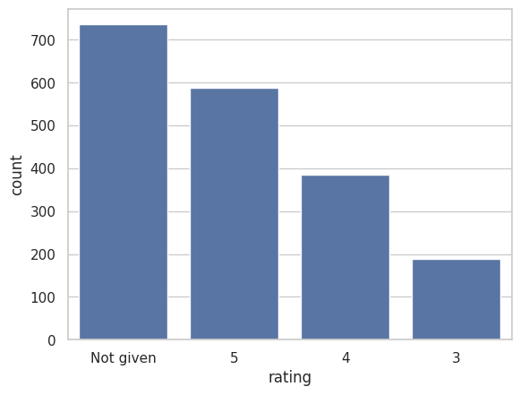

```python
sns.countplot(data = df, x = 'rating', order = df['rating'].value_counts().index) #plot ratings in descending order
```

1. There are 4 distinct ratings Notgiven,5,4,3 with no 1 or 2 ratings restaurants.
2. There are 736 with no ratings

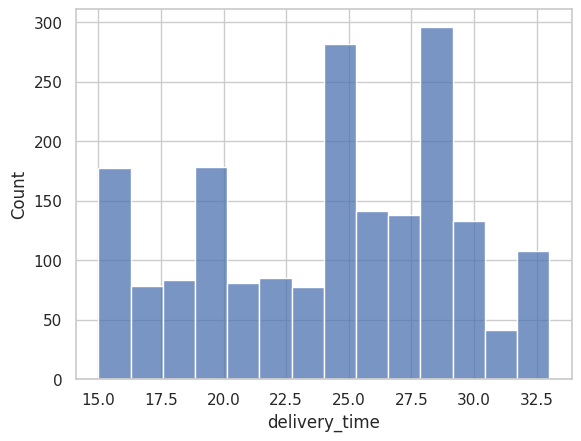

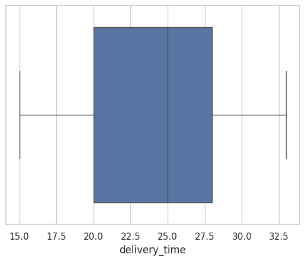

```python
sns.histplot(data=df,x='delivery_time') # plot the histogram for the delivery time
plt.show()
sns.boxplot(data=df,x='delivery_time') # plot the boxplot for the delivery time
plt.show()
```

### **Question 7**: Which are the top 5 restaurants in terms of the number of orders received? [1 mark]

```python
# Get the top 5 restuarants in terms of no. of Orders.
df['restaurant_name'].value_counts().head()
```

| restaurant_name | count |
| --- | --- |
| Shake Shack | 219 |
| The Meatball Shop | 132 |
| Blue Ribbon Sushi | 119 |
| Blue Ribbon Fried Chicken | 96 |
| Parm | 68 |

**dtype:** int64

#### Observations:

Shake Shack is the most ordered restaurant with higer number of orders compared to others.

### **Question 8**: Which is the most popular cuisine on weekends? [1 mark]

```python
# Get most popular cuisine_type on weekends
df_weekend = df[df['day_of_the_week'] == 'Weekend']
df_weekend['cuisine_type'].value_counts().head(1) # head(1) gives the top 1 cuisine type
```

| cuisine_type | count |
| --- | --- |
| American | 415 |

**dtype:** int64

#### Observations:

American is the most ordered cusine type over the weekends.

### **Question 9**: What percentage of the orders cost more than 20 dollars? [2 marks]

```python
# Create a new DataFrame that only contains orders with 'cost_of_the_order' greater than 20
df_greater_than_20 = df[df['cost_of_the_order']>20]
# Print the total number of orders that cost more than 20 dollars
print('The number of total orders that cost more then 20 dollars is:', df_greater_than_20.shape[0])
# Calculate the percentage of orders that cost more than 20 dollars
# df_greater_than_20.shape[0] gives the number of orders > $20
# df.shape[0] gives the total number of orders in the original DataFrame
percentage = (df_greater_than_20.shape[0] / df.shape[0]) * 100
# Print the percentage of orders that cost more than 20 dollars, rounded to 2 decimal places
print(f'The percentage of orders that cost more than 20 dollars is: {percentage:.2f}%')
```

```
The number of total orders that cost more then 20 dollars is: 555
The percentage of orders that cost more than 20 dollars is: 29.24%
```

#### Observations:

1. There are 555 orders that cost more then 20 dollars
2. The percentage of orders that cost more than 20 dollars is: 29.24%

### **Question 10**: What is the mean order delivery time? [1 mark]

```python
# Get the mean delivery time into a variable
mean_delv_time = df['delivery_time'].mean()
# prin the mean value rounded to 2 decimals
print('the mean order delivery time is', round(mean_delv_time ,2),'minutes')
```

```
the mean order delivery time is 24.16 minutes
```

#### Observations:

On average, orders are delivered in about 24 minutes..

### **Question 11:** The company has decided to give 20% discount vouchers to the top 5 most frequent customers. Find the IDs of these customers and the number of orders they placed. [1 mark]

```python
#  Count the number of orders for each customer and get the top 5 customers
top_customers = df['customer_id'].value_counts().head(5).reset_index()
# Rename the columns for better readability
# 'index' becomes 'customer_id' and the counts become 'number_of_orders'
top_customers.columns = ['customer_id' , 'number_of_orders']
top_customers # Display the top 5 customers with the most orders
```

|  | customer_id | number_of_orders |
| --- | --- | --- |
| 0 | 52832 | 13 |
| 1 | 47440 | 10 |
| 2 | 83287 | 9 |
| 3 | 250494 | 8 |
| 4 | 259341 | 7 |

Customer 52832 has ordered 13 times.

```python
top_customers['discount_amount'] = top_customers['number_of_orders'] * 0.2 # Calculate a discount amount for each top customer with a discount of 20%
top_customers
```

|  | customer_id | number_of_orders | discount_amount |
| --- | --- | --- | --- |
| 0 | 52832 | 13 | 2.6 |
| 1 | 47440 | 10 | 2.0 |
| 2 | 83287 | 9 | 1.8 |
| 3 | 250494 | 8 | 1.6 |
| 4 | 259341 | 7 | 1.4 |

#### Observations:

Customer 52832 has ordered 13 times, and got a discount of 20% with a 2.6 discount amount.

## Multivariate Analysis

### **Question 12**: Perform a multivariate analysis to explore relationships between the important variables in the dataset and provide observations. (It is a good idea to explore relations between numerical variables as well as relations between numerical and categorical variables) [10 marks]

```python
df.head()
```

|  | order_id | customer_id | restaurant_name | cuisine_type | cost_of_the_order | day_of_the_week | rating | food_preparation_time | delivery_time |
| --- | --- | --- | --- | --- | --- | --- | --- | --- | --- |
| 0 | 1477147 | 337525 | Hangawi | Korean | 30.75 | Weekend | Not given | 25 | 20 |
| 1 | 1477685 | 358141 | Blue Ribbon Sushi Izakaya | Japanese | 12.08 | Weekend | Not given | 25 | 23 |
| 2 | 1477070 | 66393 | Cafe Habana | Mexican | 12.23 | Weekday | 5 | 23 | 28 |
| 3 | 1477334 | 106968 | Blue Ribbon Fried Chicken | American | 29.20 | Weekend | 3 | 25 | 15 |
| 4 | 1478249 | 76942 | Dirty Bird to Go | American | 11.59 | Weekday | 4 | 25 | 24 |

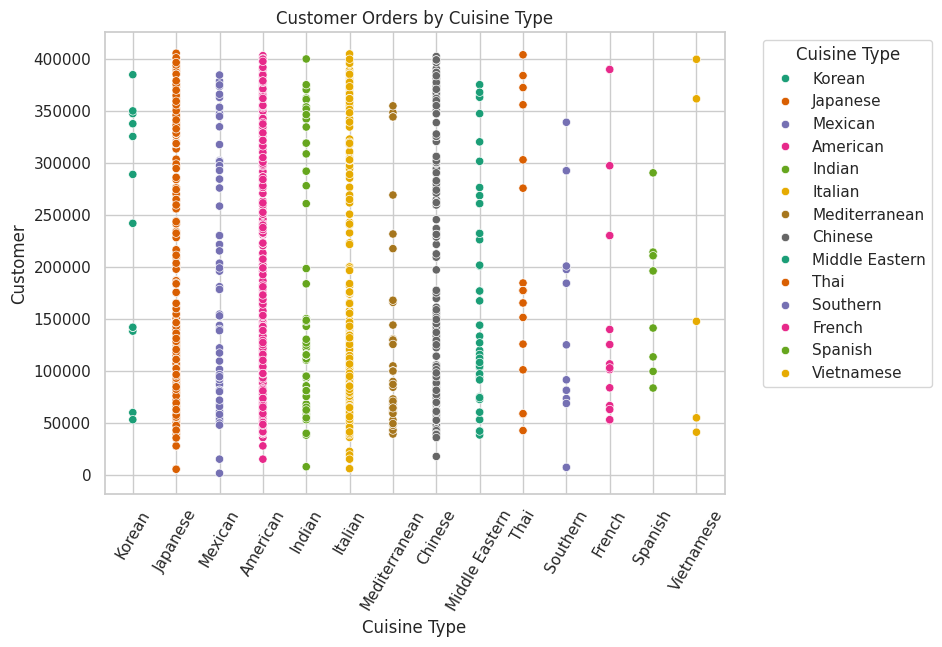

```python
#scatter plot of Customer orders for each cuisine_type
plt.figure(figsize=(8,6))
sns.scatterplot(data=df, x='cuisine_type', y='customer_id', hue='cuisine_type', palette='Dark2')
# Rotate x-axis labels for readability
plt.xticks(rotation=60)
# Add labels and title
plt.title("Customer Orders by Cuisine Type")
plt.ylabel("Customer")
plt.xlabel("Cuisine Type")
# Adjust legend
plt.legend(title='Cuisine Type', bbox_to_anchor=(1.05, 1), loc='upper left')
# Show the plot
plt.show()
```

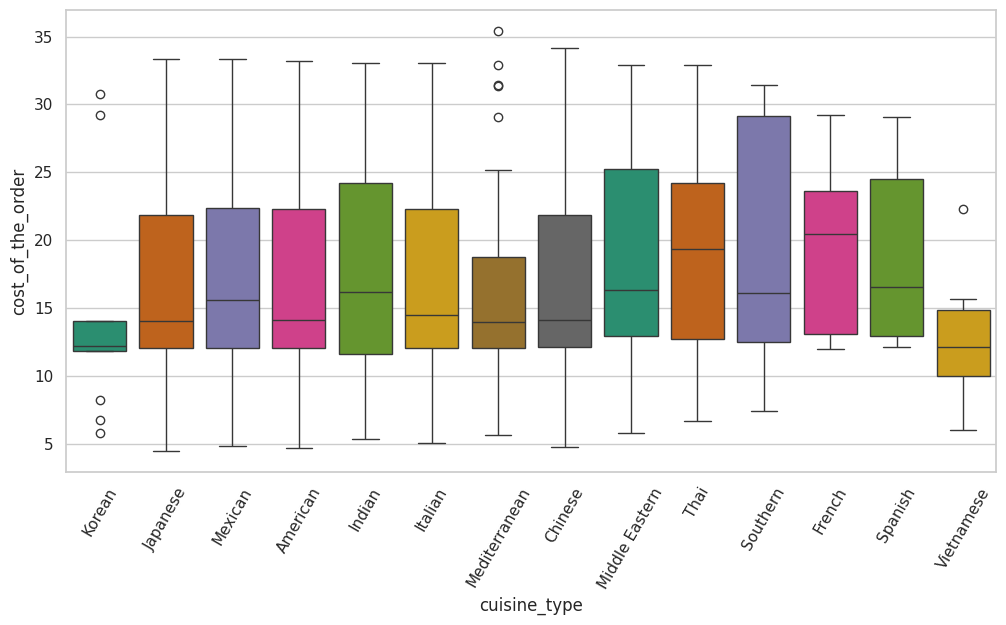

```python
#  Boxplot: Cost of Order by Cuisine Type
plt.figure(figsize=(12,6))
sns.boxplot(data=df, x='cuisine_type', y='cost_of_the_order', hue='cuisine_type', palette='Dark2')
plt.xticks(rotation = 60)
plt.show()
```

1. the most popular cuisines(American/Japanese) provide the most stable revenue stream across all price points.
2. American(median 14.12 dollars, max 33.18 dollars), Japanese(median 14.07 dollars, max 33.37 dollars), Italian (median 14.48 dollars,max 33.03 dollars), Chinese (median 14.12 dollars, max 34.19 dollars)- These appear across all price ranges.

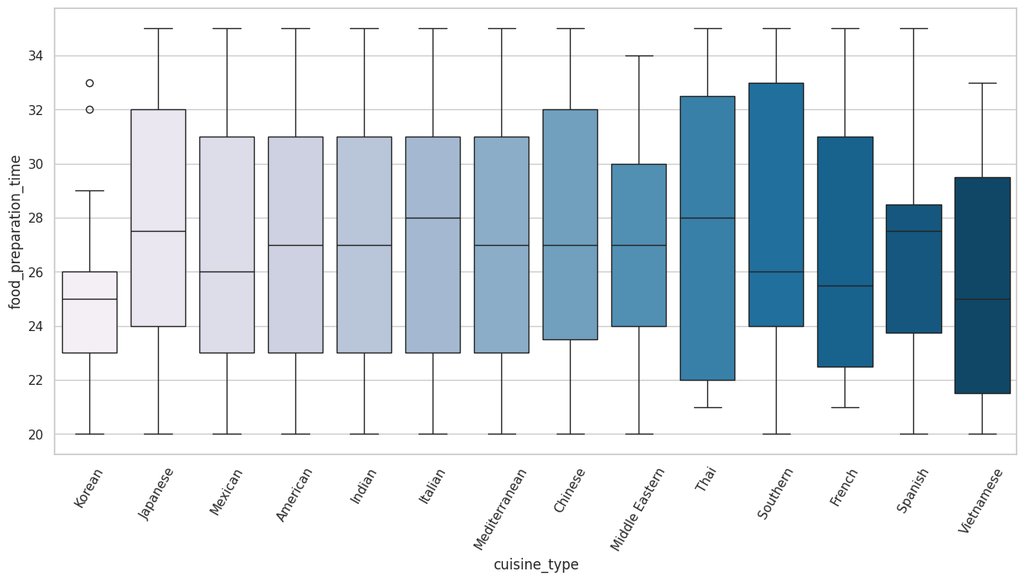

```python
# Relationship between food preparation time and cuisine type
plt.figure(figsize=(15,7))
sns.boxplot(x = "cuisine_type", y = "food_preparation_time", data = df, palette = 'PuBu', hue = "cuisine_type")
plt.xticks(rotation = 60)
plt.show()
```

1. Most cusines have a similar preparation time range between 20 and 35 minutes.
2. Most cuisines have a median preparation time centered between 25 and 28 mins.
3. Italian, Thai, and Japanese cuisines have the higher median preparation times, appearing closer to the 28-minutes .

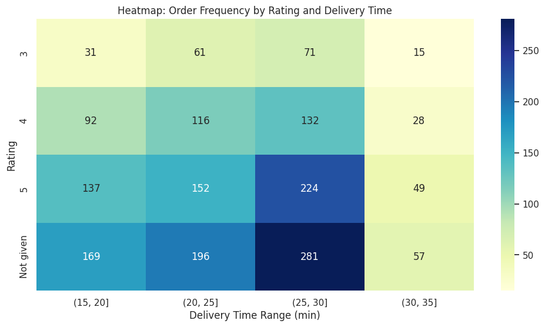

```python
#Rating vs. Food Preparation & Delivery Time
#  Create bins for delivery time
df['delivery_time_bins'] = pd.cut(df['delivery_time'], bins=[15, 20, 25, 30, 35])

#  Create a pivot table showing the count of orders for each rating and time bin
heatmap_data = df.pivot_table(index='rating', observed=False,
columns='delivery_time_bins',
values='cost_of_the_order',
aggfunc='count')

# Plot the heatmap
plt.figure(figsize=(12, 6))
sns.heatmap(heatmap_data, annot=True, fmt='g', cmap='YlGnBu')
plt.title('Heatmap: Order Frequency by Rating and Delivery Time')
plt.xlabel('Delivery Time Range (min)')
plt.ylabel('Rating')
plt.show()
```

1. The highest orders occure in 25-30 min time range who did not provide a rating value is 281.
2. Customers who actually provided a 5- star rating has a delivery time between 25-30 mins.

### **Question 13:** The company wants to provide a promotional offer in the advertisement of the restaurants. The condition to get the offer is that the restaurants must have a rating count of more than 50 and the average rating should be greater than 4. Find the restaurants fulfilling the criteria to get the promotional offer. [3 marks]

```python
# Filter out missing ratings
df_ratings = df[df['rating'] != 'Not given'].copy()

# Convert rating column datatype to int
df_ratings['rating'] = df_ratings['rating'].astype(int)

# Group by restaurant to get count and average rating
rating_count = df_ratings.groupby('restaurant_name').agg(rating_count=('rating', 'count'),average_rating=('rating', 'mean'))

# Filter for promotional eligibility
eligible_restaurants = rating_count[(rating_count['rating_count'] > 50) & (rating_count['average_rating'] > 4)]

#eligible_restaurants_sorted = eligible_restaurants.sort_values(by='rating_count', ascending=False)
eligible_restaurants_sorted = eligible_restaurants.sort_values(by='rating_count',ascending=False).reset_index()
eligible_restaurants_sorted
```

|  | restaurant_name | rating_count | average_rating |
| --- | --- | --- | --- |
| 0 | Shake Shack | 133 | 4.278195 |
| 1 | The Meatball Shop | 84 | 4.511905 |
| 2 | Blue Ribbon Sushi | 73 | 4.219178 |
| 3 | Blue Ribbon Fried Chicken | 64 | 4.328125 |

#### Observations:

The restaurants that are eligible to get the promotional offers are Shake Shack,The Meatball Shop,Blue Ribbon Sushi,3 Blue Ribbon Fried Chicken

### **Question 14:** The company charges the restaurant 25% on the orders having cost greater than 20 dollars and 15% on the orders having cost greater than 5 dollars. Find the net revenue generated by the company across all orders. [3 marks]

```python
#define a function to calculate net revenue
def cal_rev(x):
  if x > 20: #'x' is order cost if >20 then apply 25% charge on the order
    return x * 0.25
  elif x > 5: #'x' is order cost if >20 then apply 25% charge on the order
    return x * 0.15
  else:
    return x * 0
df['net_revenue'] = df['cost_of_the_order'].apply(cal_rev)
df.head()
```

|  | order_id | customer_id | restaurant_name | cuisine_type | cost_of_the_order | day_of_the_week | rating | food_preparation_time | delivery_time | delivery_time_bins | net_revenue |
| --- | --- | --- | --- | --- | --- | --- | --- | --- | --- | --- | --- |
| 0 | 1477147 | 337525 | Hangawi | Korean | 30.75 | Weekend | Not given | 25 | 20 | (15.0, 20.0] | 7.6875 |
| 1 | 1477685 | 358141 | Blue Ribbon Sushi Izakaya | Japanese | 12.08 | Weekend | Not given | 25 | 23 | (20.0, 25.0] | 1.8120 |
| 2 | 1477070 | 66393 | Cafe Habana | Mexican | 12.23 | Weekday | 5 | 23 | 28 | (25.0, 30.0] | 1.8345 |
| 3 | 1477334 | 106968 | Blue Ribbon Fried Chicken | American | 29.20 | Weekend | 3 | 25 | 15 | NaN | 7.3000 |
| 4 | 1478249 | 76942 | Dirty Bird to Go | American | 11.59 | Weekday | 4 | 25 | 24 | (20.0, 25.0] | 1.7385 |

```python
total_revenue = df['net_revenue'].sum()
print('The net revenue is around', round(total_revenue, 2), 'dollars')
```

```
The net revenue is around 6166.3 dollars
```

#### Observations:

- The net revenue generated by the company across alll orders is $6166.3

### **Question 15:** The company wants to analyze the total time required to deliver the food. What percentage of orders take more than 60 minutes to get delivered from the time the order is placed? (The food has to be prepared and then delivered.) [2 marks]

```python
df['total_time'] = df['food_preparation_time'] + df['delivery_time']

# Calculate the number of orders that take more than 60 minutes
orders_over_60_min = df[df['total_time'] > 60]
num_orders_over_60_min = orders_over_60_min.shape[0]

# Calculate the total number of orders
total_orders = df.shape[0]

# Calculate the percentage
percentage_over_60_min = (num_orders_over_60_min / total_orders) * 100

print(f"The mean total time for food preparation and delivery is: {df['total_time'].mean():.2f} minutes")
print(f"Number of orders taking more than 60 minutes: {num_orders_over_60_min}")
print(f"Percentage of orders taking more than 60 minutes: {percentage_over_60_min:.2f}%")
```

```
The mean total time for food preparation and delivery is: 51.53 minutes
Number of orders taking more than 60 minutes: 200
Percentage of orders taking more than 60 minutes: 10.54%
```

#### Observations:

The mean total time for food preparation and delivery is: 51.53 minutes Number of orders taking more than 60 minutes: 200 Percentage of orders taking more than 60 minutes: 10.54%

### **Question 16:** The company wants to analyze the delivery time of the orders on weekdays and weekends. How does the mean delivery time vary during weekdays and weekends? [2 marks]

```python
#df.describe()

# Get the mean delivery time on weekdays and print it
print('The mean delivery time on weekdays is around',
      round(df[df['day_of_the_week'] == 'Weekday']['delivery_time'].mean()),
     'minutes')
print('The mean delivery time on weekdays is around',
      round(df[df['day_of_the_week'] == 'Weekend']['delivery_time'].mean()),
     'minutes')
```

```
The mean delivery time on weekdays is around 28 minutes
The mean delivery time on weekdays is around 22 minutes
```

#### Observations:

The average delivery time is approximately 28 minutes on weekdays and 22 minutes on weekends.

```python
# Total orders on weekdays and weekends
total_weekday_orders = len(df[df['day_of_the_week'] == 'Weekday'])
total_weekend_orders = len(df[df['day_of_the_week'] == 'Weekend'])

# Orders with delivery time > 30 mins
long_weekday_orders = len(df[(df['day_of_the_week'] == 'Weekday') & (df['delivery_time'] > 30)])
long_weekend_orders = len(df[(df['day_of_the_week'] == 'Weekend') & (df['delivery_time'] > 30)])

# Calculate percentages
percentage_long_weekday = (long_weekday_orders / total_weekday_orders) * 100
percentage_long_weekend = (long_weekend_orders / total_weekend_orders) * 100

print(f"Percentage of weekday orders with delivery time > 30 mins: {percentage_long_weekday:.2f}%")
print(f"Percentage of weekend orders with delivery time > 30 mins: {percentage_long_weekend:.2f}%")
```

```
Percentage of weekday orders with delivery time > 30 mins: 27.24%
Percentage of weekend orders with delivery time > 30 mins: 0.00%
```

# Conclusion and Business Recommendations

## Business Recommendations

- FoodHub should focus on high-performing restaurants and popular cuisines (Shake Shack, The Meatball Shop, Blue Ribbon restaurants; American, Japanese, Italian, Chinese) for targeted marketing and promotions.
- Promote specialty cuisines (Thai, French, Southern, Korean, Spanish, Vietnamese) strategically through limited-time offers, combo deals, or awareness campaigns.
- Maintain preparation and delivery efficiency, ensuring most orders are delivered within 25–30 minutes to maximize customer satisfaction.
- Encourage customers to provide ratings through reminders, simplified feedback, or small incentives.
- FoodHub should introduce loyalty programs or targeted incentives to increase repeat orders.
- FoodHub should monitor cuisines with higher median preparation times (Italian, Thai, Japanese) to prevent delays during peak hours.
- Leverage popular cuisines across all price ranges to maintain a stable revenue stream.
- Use data-driven insights to tailor menu offerings, promotions, and pricing strategies effectively.
- Address weekday delivery delays: approximately 27% of weekday orders take longer than 30 minutes, so operational improvements or additional staffing may be needed to reduce delays.